# Full reference DNA pool analysis for primer set evaluation

## Data for Figure 2

Calculate the mean values per locus per replicate; alternatively, I could have three lines - one for the minimum, one for the maximum, and one for the mean.

```r
spp.per.sample.loc <- all.loci.ref.spp %>%
  filter(taxonomic_level == "species") %>%
    filter(ref_species == species) %>%
  ungroup() %>%
  select(species, locus, count, sample) %>% # here, I keep the individual sample replicates intact
  unique() %>%
  group_by(species, locus, sample) %>%
  summarise(total_count = sum(count)) %>%
  ungroup() %>%
  group_by(locus, sample) %>%
  add_tally(name = "num_species") %>%
  arrange(desc(num_species))
```

Maximum species identified per locus

```r
loc.spp.summary <- spp.per.sample.loc %>%
  group_by(locus) %>%
  mutate(max = max(num_species)) %>%
  mutate(min = min(num_species)) %>%
  mutate(mean = mean(num_species)) %>%
  mutate(sd = sd(num_species)) %>%
  select(locus, min, max, mean, sd, species)
```

Maximum genera per locus

```r
gen.spp.per.sample.loc <- all.loci.ref.spp %>%
  filter(taxonomic_level %in% c("species", "genus")) %>%
  filter(ref_genus == genus.y) %>% # this ensures that the genus is accurate to the reference genus, even if the species is not.
  ungroup() %>%
  select(ref_species, locus, count, sample) %>%
  unique() %>%
  group_by(ref_species, locus, sample) %>%
  summarise(total_count = sum(count)) %>%
  ungroup() %>%
  group_by(locus, sample) %>%
  add_tally(name = "num_taxa") %>%
  ungroup() %>%
  group_by(locus) %>%
  mutate(max = max(num_taxa)) %>%
  mutate(min = min(num_taxa)) %>%
  mutate(mean = mean(num_taxa)) %>%
  mutate(sd = sd(num_taxa)) %>%
  select(locus, min, max, mean, sd) %>%
  unique() %>%
  mutate(rank = "genus")
```

Species- through family-level per locus

```r
fam.gen.spp.per.sample.loc <- all.loci.ref.spp %>%
  filter(taxonomic_level %in% c("species", "genus", "family")) %>% # because the conditionally merged df was joined on family, the family level should be the same as the reference data
  ungroup() %>%
  select(ref_species, locus, count, sample) %>%
  unique() %>%
  group_by(ref_species, locus, sample) %>%
  summarise(total_count = sum(count)) %>%
  ungroup() %>%
  group_by(locus, sample) %>%
  add_tally(name = "num_taxa") %>%
  ungroup() %>%
  group_by(locus) %>%
  mutate(max = max(num_taxa)) %>%
  mutate(min = min(num_taxa)) %>%
  mutate(mean = mean(num_taxa)) %>%
  mutate(sd = sd(num_taxa)) %>%
  select(locus, min, max, mean, sd) %>%
  unique() %>%
  mutate(rank = "family")
```

```r
# combine the species- genus- and family-level taxonomic matches to reference species by locus
overall.loc.summary <- loc.spp.summary %>%
  select(locus, min, max, mean, sd) %>%
  unique() %>%
  mutate(rank = "species") %>%
  bind_rows(., gen.spp.per.sample.loc) %>%
  bind_rows(., fam.gen.spp.per.sample.loc) %>%
  left_join(., uniques)
```

```r
# loc.plot2 <- overall.loc.summary %>%
#   ggplot(aes(x = reorder(locus, -mean), y = mean, color = rank, shape = rank)) +
#    geom_errorbar(aes(ymin=mean-sd, ymax=mean+sd), width=.1) +
#       geom_point(alpha = 0.8) +
#     theme_bw() +
#   ylab("Reference species") +
#   xlab("Locus") +
#   #scale_color_manual(values = c("midnightblue", "royalblue1", "lightskyblue")) +
#   scale_color_manual(values = c("black", "gray42", "gray62")) +
#   scale_y_continuous(limits = c(0, 103))
#
# loc.plot2 + theme(
#   axis.text.x = element_text(angle = 90, hjust = 0.95),
#                              legend.position = c(0.8, 0.8)
# )
```

## Aquateam feedback - 27 May 2020

A couple of useful comments from the group: 1. Add a plot that includes the info of Figure 1 (locus accumulation curve), but using the proportion of species/genera/families identified by each locus in a cumulative fashion.

I should be able to derive that info from my existing species accumulation curves

## Rank accumulation curves

We can visually capture the combinatorial power of the loci using rank accumulation curves where the locus that resolves the most species in our mock community is first and each additional locus is ordered and added to contribute to the overall number of known taxa.

Create one curve, ordered by the number of species that a given locus resolves. This can be done in the package “vegan” by ordering the loci and then setting method = “collector.”

Rather than defaulting to ordering the loci by total number of species recovered, I manually adjusted the “collector” locus order because the rank according to # of species doesn’t take complementarity into account.

| locus | Alopias_vulpinus | Anchoa_hepsetus | Antigonia_capros | Bairdiella_chrysoura | Benthosema_pterotum | Brevoortia_tyrannus | Carcharhinus_plumbeus | Centropristis_philadelphica | Chaetodipterus_faber | Citharichthys_arctifrons | Cololabis_saira | Conger_oceanicus | Cynoscion_regalis | Dasyatis_say | Decapterus_punctatus | Engraulis_japonicus | Engraulis_mordax | Etrumeus_teres | Euphausia_superba | Euthynnus_affinis | Fistularia_petimba | Hypanus_americanus | Lagodon_rhomboides | Larimus_fasciatus | Leiognathus_equulus | Leiostomus_xanthurus | Leucoraja_garmani | Litopeneaus_vannamei | Lophius_americanus | … |
| --- | --- | --- | --- | --- | --- | --- | --- | --- | --- | --- | --- | --- | --- | --- | --- | --- | --- | --- | --- | --- | --- | --- | --- | --- | --- | --- | --- | --- | --- | --- |
| fishminiA | 38 | 38 | 38 | 0 | 38 | 0 | 0 | 38 | 38 | 38 | 38 | 38 | 38 | 38 | 38 | 0 | 38 | 38 | 0 | 38 | 38 | 38 | 38 | 38 | 0 | 0 | 38 | 0 | 38 | … |
| mifish | 26 | 0 | 0 | 26 | 26 | 26 | 26 | 0 | 26 | 0 | 26 | 26 | 26 | 0 | 0 | 26 | 26 | 0 | 0 | 0 | 26 | 0 | 26 | 0 | 0 | 26 | 0 | 0 | 0 | … |
| nsCOIFo | 34 | 0 | 34 | 0 | 34 | 34 | 0 | 34 | 34 | 34 | 0 | 34 | 0 | 34 | 34 | 0 | 34 | 34 | 34 | 0 | 0 | 34 | 34 | 34 | 0 | 0 | 34 | 34 | 34 | … |
| aquaF2 | 32 | 32 | 0 | 0 | 32 | 32 | 0 | 0 | 32 | 32 | 0 | 32 | 32 | 32 | 32 | 0 | 32 | 32 | 0 | 0 | 0 | 32 | 32 | 32 | 0 | 0 | 32 | 32 | 32 | … |
| cep | 25 | 25 | 25 | 25 | 25 | 0 | 0 | 0 | 25 | 0 | 0 | 25 | 0 | 0 | 0 | 0 | 0 | 25 | 0 | 0 | 25 | 25 | 25 | 0 | 25 | 0 | 0 | 0 | 0 | … |
| fishcoilbc | 23 | 23 | 0 | 0 | 23 | 0 | 0 | 23 | 23 | 23 | 0 | 23 | 23 | 23 | 23 | 0 | 0 | 23 | 0 | 0 | 0 | 23 | 23 | 23 | 0 | 0 | 0 | 0 | 23 | … |
| aquaF3 | 26 | 26 | 0 | 0 | 26 | 26 | 0 | 26 | 26 | 0 | 0 | 26 | 26 | 26 | 0 | 0 | 26 | 26 | 0 | 0 | 0 | 26 | 26 | 26 | 0 | 0 | 26 | 0 | 26 | … |
| plankCOI | 23 | 0 | 0 | 0 | 23 | 0 | 0 | 23 | 23 | 23 | 0 | 23 | 23 | 23 | 23 | 0 | 0 | 23 | 0 | 0 | 0 | 23 | 23 | 23 | 0 | 0 | 0 | 0 | 23 | … |
| 16Svar | 0 | 12 | 12 | 0 | 0 | 0 | 0 | 0 | 12 | 0 | 0 | 12 | 0 | 0 | 0 | 0 | 0 | 12 | 0 | 0 | 0 | 0 | 0 | 0 | 0 | 0 | 0 | 0 | 0 | … |
| sharkCOImini | 23 | 0 | 0 | 0 | 23 | 0 | 0 | 23 | 23 | 23 | 0 | 23 | 23 | 23 | 23 | 0 | 0 | 23 | 0 | 0 | 0 | 23 | 23 | 23 | 0 | 0 | 0 | 0 | 23 | … |

[output cut: 11 more lines]

| locus |
| --- |
| fishminiA |
| nsCOIFo |
| aquaF2 |
| aquaF3 |
| shark474 |
| cep |
| mifish |
| fishcoilbc |
| plankCOI |
| sharkCOImini |

[output cut: 11 more lines]

### genus and species accumulation…

```r
genus.ordered.all.loc <- all.loci.ref.spp %>%
  filter(taxonomic_level %in% c("species", "genus")) %>% # consensus taxonomy = either spp or genus
  ungroup() %>%
  filter(ref_species == species | ref_genus == genus) %>% # either a match to the correct species or genus
  select(ref_species, locus, count) %>% # make sure there are no duplicates that will cause double-counting.
  unique() %>%
  group_by(locus, ref_species) %>%
  summarise(total_count = sum(count)) %>% # sum the read counts for the same species in the same sample/locus
  ungroup() %>%
  group_by(locus) %>% # tally the number of species identified by each locus (in each replicate)
  add_tally(name = "num_taxa") %>%
  arrange(desc(num_taxa)) %>%
  ungroup() %>%
  select(locus, ref_species, num_taxa)
# explicitly set the factor levels
genus.ordered.all.loc$locus <- factor(genus.ordered.all.loc$locus, levels = c("fishminiA", "mifish", "nsCOIFo", "aquaF2", "cep", "fishcoilbc", "aquaF3", "plankCOI",  "16Svar","sharkCOImini", "short28S", "16SH1",  "shark474", "minibar",  "crust16S", "18Sn4", "18SSSU3", "ceph16S", "L2513H2714", "teleo", "16Sfish", "crust2"))


# reformat
wide_ordered.genus.spp <- dcast(genus.ordered.all.loc, locus ~ ref_species, value.var = "num_taxa", fun.aggregate = sum)

# change the sample column into rownames
wide_ordered.gen.spp.tbl <- column_to_rownames(wide_ordered.genus.spp, loc = 1)
accurve.ordered.genus.spp <-specaccum(wide_ordered.gen.spp.tbl, method="collector", permutations = 1000)

# calculate proportions
genus_loc_prop <- as.data.frame(accurve.ordered.genus.spp$richness) %>%
  rownames_to_column(var = "locus") %>%
  mutate(proportion = accurve.ordered.genus.spp$richness/max(accurve.ordered.genus.spp$richness)) %>%
  mutate(taxon_level = "genus")
```

```r
fam.ordered.all.loc <- all.loci.ref.spp %>%
  filter(taxonomic_level %in% c("species", "genus", "family")) %>% # the df is merged on family, so in all cases, the family-level taxonomy should be correct
  ungroup() %>%
  select(ref_species, locus, count) %>% # make sure there are no duplicates that will cause double-counting.
  unique() %>%
  group_by(locus, ref_species) %>%
  summarise(total_count = sum(count)) %>% # sum the read counts for the same species in the same locus
  ungroup() %>%
  group_by(locus) %>% # tally the number of species identified by each locus
  add_tally(name = "num_taxa") %>%
  arrange(desc(num_taxa)) %>%
  ungroup() %>%
  select(locus, ref_species, num_taxa)
# explicitly set the factor levels
fam.ordered.all.loc$locus <- factor(fam.ordered.all.loc$locus, levels = c("fishminiA", "mifish", "nsCOIFo", "aquaF2", "cep", "fishcoilbc", "aquaF3", "plankCOI",  "16Svar","sharkCOImini", "short28S", "16SH1",  "shark474", "minibar",  "crust16S", "18Sn4", "18SSSU3", "ceph16S", "L2513H2714", "teleo", "16Sfish", "crust2"))

# reformat
wide_ordered.fam <- dcast(fam.ordered.all.loc, locus ~ ref_species, value.var = "num_taxa", fun.aggregate = sum)

# change the sample column into rownames
wide_ordered.fam.tbl <- column_to_rownames(wide_ordered.fam, loc = 1)
accurve.ordered.fam <-specaccum(wide_ordered.fam.tbl, method="collector", permutations = 1000)

# generate proportions
family_loc_prop <- as.data.frame(accurve.ordered.fam$richness) %>%
  rownames_to_column(var = "locus") %>%
  mutate(proportion = accurve.ordered.fam$richness/max(accurve.ordered.fam$richness)) %>%
  mutate(taxon_level = "family")
```

```r
# combine those
loc_accum_prop_combo <- bind_rows(species_loc_prop_df, genus_loc_prop, family_loc_prop) %>%
  #select(locus, proportion, taxon_level) %>%
  ungroup() %>%
  group_by(taxon_level) %>%
  rename(richness = `sp1$richness`) %>%
  mutate(richness = ifelse(taxon_level == "genus", `accurve.ordered.genus.spp$richness`, richness)) %>%
    mutate(richness = ifelse(taxon_level == "family", `accurve.ordered.fam$richness`, richness)) %>%
  select(locus, richness, proportion, taxon_level)

# factor levels
loc_accum_prop_combo$locus <- factor(loc_accum_prop_combo$locus)

loc_accum_prop_combo %>%
  arrange(proportion)
```

| locus | richness | proportion | taxon_level |
| --- | --- | --- | --- |
| fishminiA | 38 | 0.6229508 | species |
| fishminiA | 73 | 0.7448980 | genus |
| mifish | 49 | 0.8032787 | species |
| mifish | 85 | 0.8673469 | genus |
| fishminiA | 90 | 0.8737864 | family |
| nsCOIFo | 56 | 0.9180328 | species |
| nsCOIFo | 92 | 0.9387755 | genus |
| mifish | 97 | 0.9417476 | family |
| aquaF2 | 94 | 0.9591837 | genus |
| aquaF2 | 59 | 0.9672131 | species |

[output cut: 55 more lines]

```r
NA
```

```r
# use expand to fill in the species-level for L2513H2714
loc_accum_prop_filled <- loc_accum_prop_combo %>%
  expand(taxon_level, locus) %>%
  left_join(., loc_accum_prop_combo) %>%
  mutate(richness = ifelse(is.na(richness), 61, richness)) %>%
    mutate(proportion = ifelse(is.na(proportion), 1, proportion))
```

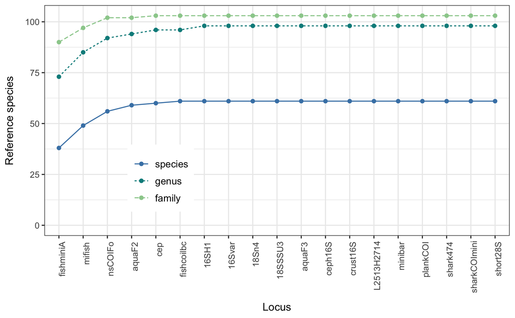

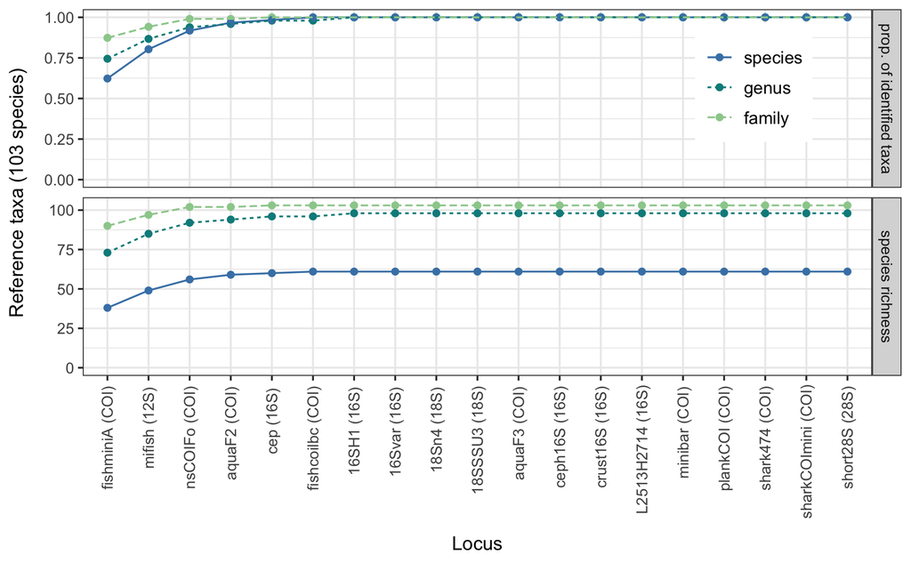

```r
# two panels for the accumulation plot
dual_panel_df <- loc_accum_prop_combo_minus_3 %>%
  pivot_longer(cols = 3:4, names_to = "y_axis", values_to = "value") %>%
  mutate(y_axis = ifelse(y_axis == "proportion", "prop. of identified taxa", "species richness")) %>%
  mutate(gene = ifelse(locus %in% c("fishminiA", "nsCOIFo", "shark474", "aquaF3", "aquaF2", "plankCOI", "fishcoilbc", "sharkCOImini", "minibar", "crust2"), "COI", "16S")) %>%
  mutate(gene = ifelse(locus %in% c("mifish", "teleo"), "12S", gene)) %>%
    mutate(gene = ifelse(str_detect(locus, "18S"), "18S", gene)) %>%
        mutate(gene = ifelse(str_detect(locus, "28S"), "28S", gene)) %>%
  mutate(gene = paste0("(",gene,")")) %>%
  unite(loc.gene, locus, gene, sep = " ", remove = F)

 testplot2 <- dual_panel_df %>%
   ggplot() +
  geom_point(aes(x = reorder(loc.gene, value), y = value, color = tax2)) +
  geom_line(aes(x = reorder(loc.gene, value), y = value, color = tax2, group = tax2, linetype = tax2)) +
  theme_bw() +
  expand_limits(y = 0) +
  xlab("Locus") +
  ylab("Reference taxa (103 species)") +
  labs(color = "Taxonomic rank") +
    labs(linetype = "Taxonomic rank") +
  scale_color_manual(values = my_pal)

testplot2 + facet_grid(rows = vars(y_axis), scales = "free_y") +
  theme(
    axis.text.x = element_text(angle = 90, hjust = 0.95, vjust = 0.5),
    axis.title.x = element_text(margin = margin(t = 10), size = 11),
    axis.title.y = element_text(margin = margin(r = 10), size = 11),
    legend.text = element_text(size = 10),
    #legend.title = element_text(size = 12),
    legend.position=c(.85,0.8),
    legend.title = element_blank()
  )

ggsave("pdf_outputs/taxa_accumulation_curves_downsampled.pdf", width = 7, height = 5)
```

```r
# This will be the canonical order of the loci for this set of figures
loc.list <- dual_panel_df %>%
  filter(y_axis == "species richness" & tax2 == "genus") %>%
  arrange(value) %>%
  ungroup() %>%
  select(loc.gene) %>%
  as.list()

loc.list$loc.gene
```

```
 [1] "fishminiA (COI)"    "mifish (12S)"       "nsCOIFo (COI)"      "aquaF2 (COI)"
 [5] "cep (16S)"          "fishcoilbc (COI)"   "16SH1 (16S)"        "16Svar (16S)"
 [9] "18Sn4 (18S)"        "18SSSU3 (18S)"      "aquaF3 (COI)"       "ceph16S (16S)"
[13] "crust16S (16S)"     "L2513H2714 (16S)"   "minibar (COI)"      "plankCOI (COI)"
[17] "shark474 (COI)"     "sharkCOImini (COI)" "short28S (28S)"
```

```r
loc_levels <- loc.list$loc.gene
dual_panel_df$loc.gene <- factor(dual_panel_df$loc.gene, levels = loc_levels)
levels(dual_panel_df$loc.gene)
```

```
 [1] "fishminiA (COI)"    "mifish (12S)"       "nsCOIFo (COI)"      "aquaF2 (COI)"
 [5] "cep (16S)"          "fishcoilbc (COI)"   "16SH1 (16S)"        "16Svar (16S)"
 [9] "18Sn4 (18S)"        "18SSSU3 (18S)"      "aquaF3 (COI)"       "ceph16S (16S)"
[13] "crust16S (16S)"     "L2513H2714 (16S)"   "minibar (COI)"      "plankCOI (COI)"
[17] "shark474 (COI)"     "sharkCOImini (COI)" "short28S (28S)"
```

```r
loc_info <- dual_panel_df %>%
  ungroup() %>%
  select(locus, loc.gene)
```

```r
loc.summary <- overall.loc.summary %>%
  left_join(loc_info) %>%
  unique()
loc.summary$rank <- factor(loc.summary$rank, levels = c("species", "genus", "family"))
loc.summary$loc.gene <- factor(loc.summary$loc.gene, levels = loc_levels)
```

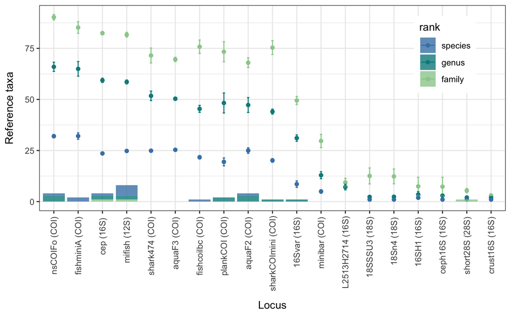

## NOT SURE IF I WANT TO KEEP THIS IN HERE.

## Locus length and taxonomic resolution

Does locus-length relate to taxonomic resolution?

```r
# read in the product length data
# loc_lengths <- read_csv("../data/loc_lengths.csv") %>%
#   filter(!is.na(locus))
#
# ll_plot <- loc_lengths %>%
#   ggplot(aes(x = reorder(locus, product), y = product)) +
#   geom_point() +
#   theme_minimal() +
#   ylab("Product size (bp)") +
#   xlab("Locus")
#
# ll_plot + theme(
#   axis.text.x = element_text(angle = 90),
#   axis.title.y = element_text(margin = margin(r = 10))
# )
#
# ggsave("pdf_outputs/locus_length.pdf", height = 4, width = 7)
#
# # gene identities
# genes <- read_csv("../data/loc_genes.csv")
```

```r
# set colors
# cbp1 <- c("#E69F00", "#56B4E9", "#009E73","#660066",
#            "#0072B2", "#D55E00", "#CC79A7")
#
#
# length_plot_ranks <- loc_lengths %>%
#   mutate(locus = ifelse(locus == "Shark474", "shark474", locus)) %>%
#   mutate(locus = ifelse(locus == "Short28S", "short28S", locus)) %>%
#     left_join(., genes) %>%
#   left_join(., loc.summary) %>%
#     filter(rank == "species") %>%
#   unique() %>%
#   ggplot(aes(x = product, y = mean, color = gene)) +
#    geom_errorbar(aes(ymin=mean-sd, ymax=mean+sd), width=.1) +
#     geom_point(alpha = 0.8) +
#     theme_bw() +
#   ylab("Reference species") +
#   xlab("Locus length (bp)") +
#   labs(color = "Barcoding gene") +
#   scale_color_manual(values = orpink)
#
#
# length_plot_ranks + theme(
#   axis.text.x = element_text(angle = 90, hjust = 0.95),
#   axis.title.x = element_text(margin = margin(t = 10)),
#     axis.title.y = element_text(margin = margin(r = 10)),
#   #legend.title = element_blank(),
#                              #legend.position = c(0.9, 0.85)
# )

#ggsave("pdf_outputs/locus_length_by_reference_spp_all_ranks.pdf", width = 7, height = 3.5)
```

# Additional ways to evaluate the primer sets

## Reference database

Summarize the number of reference species per gene region for Supporting Information.

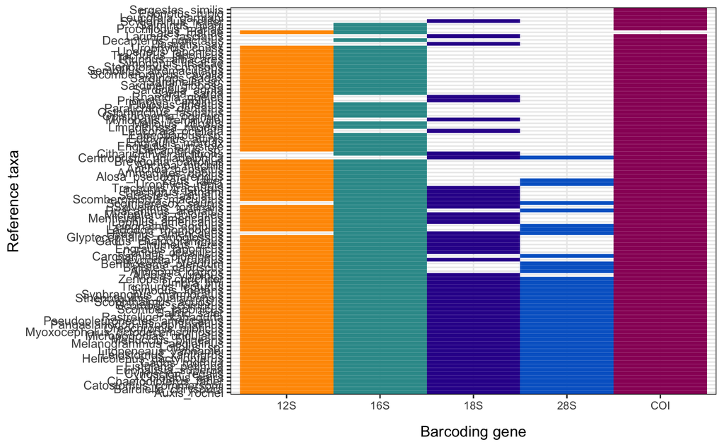

```r
# color scale
orpink <- c("#FF9900", "#339999", "#330099", "#0066CC", "#990066")


gene_db_plot <- reference_spp %>%
  pivot_longer(cols = 5:9, names_to = "gene", values_to = "blast_entries") %>%
  mutate(db_presence = ifelse(blast_entries > 0, 1, 0)) %>%
  select(species, gene, blast_entries, db_presence) %>%
  unique() %>%
  filter(db_presence > 0) %>%
  mutate(gene = ifelse(gene == "16", "16S", gene)) %>%
  mutate(gene = ifelse(gene == "12s", "12S", gene)) %>%
  mutate(gene = ifelse(gene == "18s", "18S", gene)) %>%
  mutate(gene = ifelse(gene == "28s", "28S", gene)) %>%
  group_by(gene) %>%
  add_tally(name = "n_ref_spp") %>%
  ungroup() %>%
  group_by(species) %>%
  add_tally(name = "n_genes") %>%
  ggplot(aes(x = reorder(species, -n_genes), y = gene)) +
  geom_tile(aes(fill = gene)) +
  theme_bw() +
  coord_flip() +
  xlab("Reference taxa") +
  ylab("Barcoding gene") +
  scale_fill_manual(values = orpink)

gene_db_plot + theme(
  legend.position = "none",
  axis.text.x = element_text(size = 8),
  axis.title.x = element_text(margin = margin(t = 10))
)
```

```r
#ggsave("pdf_outputs/gene_database_summary_v2.pdf", height = 12, width = 6)
```

| species | COI | 12s | 16 | 18s | 28s |
| --- | --- | --- | --- | --- | --- |
| Alopias_vulpinus | 1 | 1 | 1 | 1 | 0 |
| Alosa_pseudoharengus | 1 | 1 | 1 | 0 | 0 |
| Ammodytes_dubius | 1 | 1 | 1 | 0 | 0 |
| Anchoa_hepsetus | 1 | 1 | 1 | 0 | 0 |
| Anchoa_mitchilli | 1 | 1 | 1 | 0 | 0 |
| Antigonia_capros | 1 | 1 | 1 | 0 | 1 |
| Auxis_rochei | 1 | 1 | 1 | 1 | 1 |
| Bairdiella_chrysoura | 1 | 1 | 1 | 1 | 1 |
| Balistes_capriscus | 1 | 1 | 1 | 0 | 1 |
| Benthosema_pterotum | 1 | 1 | 1 | 0 | 1 |

[output cut: 93 more lines]

The simple way to reframe these data is by looking at the ratio of species identified by the marker that are present in the barcoding gene.

```r
ref_db_long %>%
  full_join(reference_spp) %>%
  left_join(spp_locus_gene_df) %>%
  select(locus, barcode,  species, db_presence, present)
```

| locus | barcode | species | db_presence | present |
| --- | --- | --- | --- | --- |
| aquaF2 | COI | Alopias_vulpinus | 1 | yes |
| aquaF3 | COI | Alopias_vulpinus | 1 | yes |
| fishcoilbc | COI | Alopias_vulpinus | 1 | yes |
| fishminiA | COI | Alopias_vulpinus | 1 | yes |
| nsCOIFo | COI | Alopias_vulpinus | 1 | yes |
| shark474 | COI | Alopias_vulpinus | 1 | yes |
| sharkCOImini | COI | Alopias_vulpinus | 1 | yes |
| plankCOI | COI | Alopias_vulpinus | 1 | yes |
| mifish | 12S | Alopias_vulpinus | 1 | yes |
| cep | 16S | Alopias_vulpinus | 1 | yes |

[output cut: 703 more lines]

The issue with this is that we need two categories: 1) missing bec the database doesn’t include those species for that barcode, or 2) missing bec the primer set doesn’t pick up the species (to species-resolution) even if it exists in the database.

For those species that are present in the database, but aren’t getting to species, it’s quite possible they are identified at a higher (genus/family) taxonomic level.

## Read depth vs. number of reference taxa identified

Does increased read depth correspond to increased taxonomic resolution or additional taxa identified?

```r
reads_taxa <- features_taxa_df %>%
  select(locus, seq, sample, count, taxon) %>%
  unique() %>%
  group_by(locus) %>%
  summarise(reads_per_loc = sum(count)) %>%
  left_join(., loc.summary) %>%
  #filter(rank == "species") %>%
  ggplot(aes(reads_per_loc, mean, color = rank, shape = rank)) +
  geom_point(size = 2) +
  theme_minimal() +
  xlab("Reads per locus") +
  ylab("Reference taxa (mean per locus)") +
  scale_color_manual(values = my_pal)

reads_taxa +
  theme(
    #axis.text.x = element_text(angle = 90),
    axis.title.x = element_text(margin = margin(t = 10)),
        axis.title.y = element_text(margin = margin(r = 10)))

#ggsave("pdf_outputs/reads_per_locus_by_reference_taxa_shapes.pdf", width = 6, height = 4)
```

[output not shown]